# Final Project

Hunter Garrison, Kevin Smith, Reese Madsen, Giulio Martini

2024-04-26

# Section 1: Introduction

In this project, we are working with a dataset comprising of the observed prices of houses and corresponding attributes of each house. This dataset is from the database website Kaggle and is comprised of 545 observations of houses in India with 13 variables recorded for each specific house. Below are the attributes of each house recorded in the dataset:

| Attribute | Description | Data Type |
| --- | --- | --- |
| **price** | Price of the houses in rupees. (this is our response variable) | Integer |
| area | Area of a house in square feet | Integer |
| bedrooms | Number of bedrooms in house | Integer |
| bathrooms | Number of bathrooms in house | Integer |
| stories | Number of stories in house | Integer |
| mainroad | Whether or not house is connected to main road | Boolean |
| guestroom | Whether or not house has a guest room | Boolean |
| basement | Whether or not house has a basement | Boolean |
| hotwaterheating | Whether or not house has a hot-water heater | Boolean |
| airconditioning | Whether or not house has air conditioning | Boolean |
| parking | Number of parking spots at house | Integer |
| prefarea | Whether or not the house is in a preferred area | Boolean |
| furnishingstatus | Furnishing status of the house (furnished, semi-furnished, unfurnished) | String |

The majority of our predictors in this dataset are of type boolean, with the remainders being integers and one categorical predictor comprising of strings. Below is the first 5 lines of our dataset:

| price | area | bedrooms | bathrooms | stories | mainroad | guestroom | basement |
| --- | --- | --- | --- | --- | --- | --- | --- |
| 13300000 | 7420 | 4 | 2 | 3 | yes | no | no |
| 12250000 | 8960 | 4 | 4 | 4 | yes | no | no |
| 12250000 | 9960 | 3 | 2 | 2 | yes | no | yes |
| 12215000 | 7500 | 4 | 2 | 2 | yes | no | yes |
| 11410000 | 7420 | 4 | 1 | 2 | yes | yes | yes |

| hotwaterheating | airconditioning | parking | prefarea | furnishingstatus |
| --- | --- | --- | --- | --- |
| no | yes | 2 | yes | furnished |
| no | yes | 3 | no | furnished |
| no | no | 2 | yes | semi-furnished |
| no | yes | 3 | yes | furnished |
| no | yes | 2 | no | furnished |

We are attempting to create a linear regression model that best explains the variance in the price of the houses using the predictors in our dataset. In this report, we will explore our data by finding collinearity, outliers, influential points, and by checking error assumption violations. We will also discover which variables are the most important by using variable selection, and test OLS as well as GLS and WLS regressions. After doing this, we will combine all the knowledge we have gained about our data set in order to find the model in which we believe best explains the variance in the price of the houses.

We will now perform some exploratory data analysis to show the distribution of our response variable as well as some key relationships in this dataset. Below is a histogram of our response variable, price, as well as a table showing some key statistical information about the response:

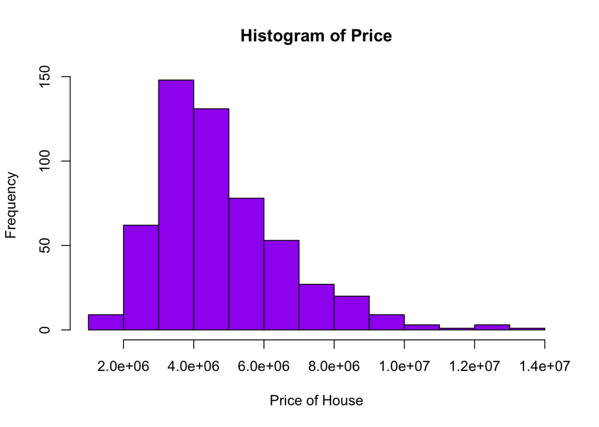

```
##       Min      Q1  Median    Mean      Q3      Max NA_Count
## 1 1750000 3430000 4340000 4766729 5740000 13300000        0
```

From our histogram and table, we see that our data is right skewed with a small amount of houses showing prices much farther than the mean. These houses may get removed as outliers later on in our report. Below, we also show a scatter plot of price vs. area:

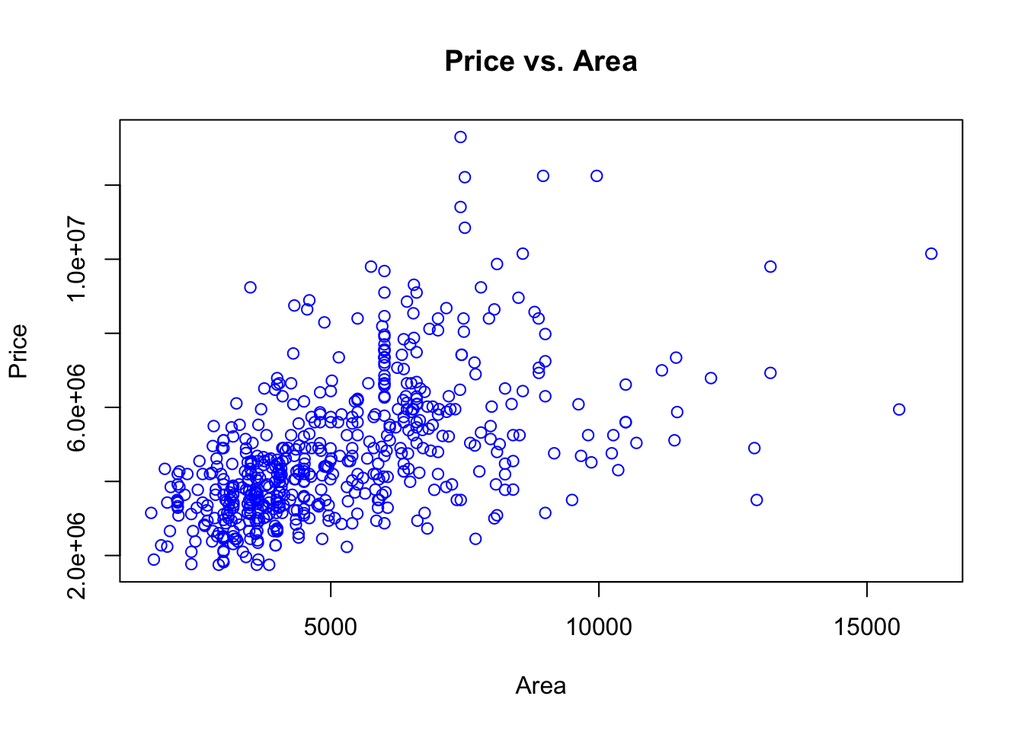

All in all, this dataset is very interesting to us because of how it can teach us the relationships between a house’s price and attributes about the house and can help us better understand the housing market when we need to go out and purchase a house for ourselves.

# Section 2: Regression Analysis

### Collinearity

In our study of the dataset we must ask ourselves whether or not the data is plagued by the issue of collinearity. Do the predictors present a linear relationship, not just with the response, but within each other as well? Collinearity can hurt a model’s performance; inflated R^2 scores and diminished p-values are but a few of the problems that arise alongside predictor collinearity… and so, the dataset must be tested for it.

Let us begin by creating a *correlation heat-map* for each predictor. This measures the correlation between predictors, and provides us with a visual method of estimating it. Each categorical column is *label encoded* - their class value is turned to a constant integer - and is added to the correlation matrix.

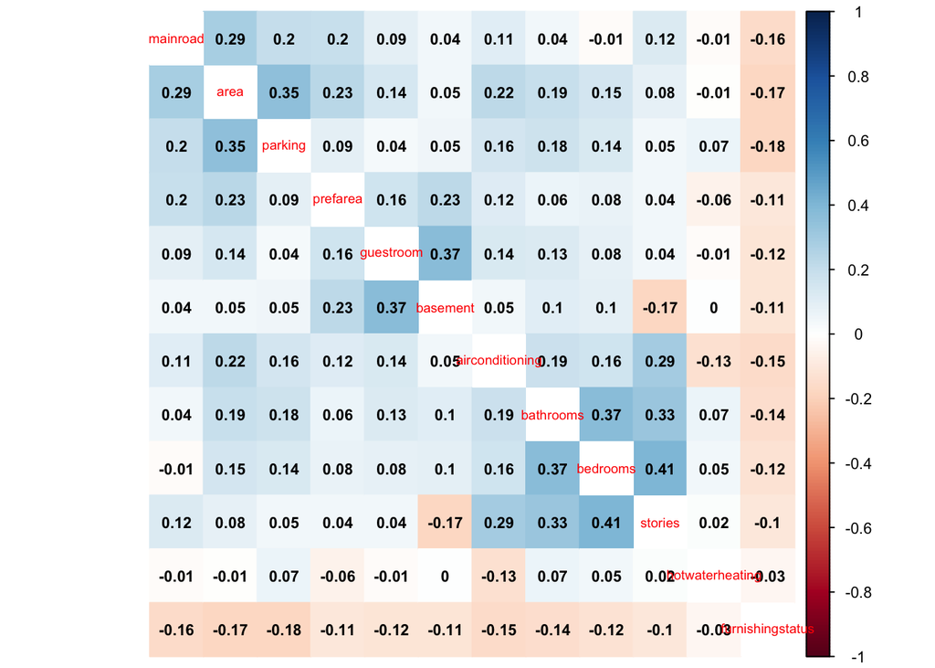

The next step is viewing the dataset’s condition numbers, based on a linear model’s (that is using the dataset) values.

| Eigenvalue | Condition Index |
| --- | --- |
| 11.4591 | 1.0000 |
| 0.5846 | 4.4275 |
| 0.2140 | 7.3182 |
| 0.1537 | 8.6333 |
| 0.1229 | 9.6550 |
| 0.1016 | 10.6223 |
| 0.0886 | 11.3721 |
| 0.0778 | 12.1358 |
| 0.0622 | 13.5738 |
| 0.0569 | 14.1939 |
| 0.0403 | 16.8673 |
| 0.0309 | 19.2715 |
| 0.0075 | 38.9969 |

The condition number is 38.9969, and usually a value above 30 marks the dataset for collinearity. This value of condition number suggests that collinearity should be a problem in this dataset. To further confirm this hypothesis, we shall check each predictor’s VIF value.

| Variable | VIF |
| --- | --- |
| area | 1.325208 |
| bedrooms | 1.367503 |
| bathrooms | 1.286559 |
| stories | 1.478029 |
| mainroad | 1.172661 |
| guestroom | 1.212687 |
| basement | 1.320749 |
| hotwaterheating | 1.039293 |
| airconditioning | 1.207262 |
| parking | 1.211959 |
| prefarea | 1.148598 |
| furnishingstatus | 1.095641 |

Only predictors with VIFs above 5 are considered problematic, however we can see that, in this dataset, the highest VIF value is 1.478029. We could stop, however we wish to make the investigation very thorough.

We can then check if the variables are orthogonal. An orthogonal variable is not plagued by multicollinearity, and has a R^2_k of less than 0.3. Below is a table of these values for each predictor:

| Variable | $R^2_k$ |
| --- | --- |
| area | 0.24540168 |
| bedrooms | 0.26874003 |
| bathrooms | 0.2273304 |
| stories | 0.32342322 |
| mainroad | 0.14723849 |
| guestroom | 0.17538517 |
| basement | 0.24285414 |
| hotwaterheating | 0.03780781 |
| airconditioning | 0.17167947 |
| parking | 0.17488936 |
| prefarea | 0.12937340 |
| furnishingstatus | 0.08729247 |

We can see that most predictors are orthogonal, with the exception of *stories* which has a value of 0.3234.

| Eigenvalue | Condition Index | intercept | area | bedrooms | bathrooms | stories |
| --- | --- | --- | --- | --- | --- | --- |
| 11.459 | 1.000 | 0.000 | 0.001 | 0.000 | 0.001 | 0.001 |
| 0.585 | 4.428 | 0.000 | 0.003 | 0.000 | 0.000 | 0.001 |
| 0.214 | 7.318 | 0.000 | 0.001 | 0.004 | 0.036 | 0.340 |
| 0.154 | 8.633 | 0.001 | 0.070 | 0.000 | 0.008 | 0.008 |
| 0.123 | 9.655 | 0.000 | 0.467 | 0.005 | 0.108 | 0.001 |
| 0.102 | 10.622 | 0.000 | 0.177 | 0.004 | 0.472 | 0.093 |
| 0.089 | 11.372 | 0.000 | 0.011 | 0.003 | 0.006 | 0.083 |
| 0.078 | 12.136 | 0.000 | 0.096 | 0.000 | 0.180 | 0.123 |
| 0.062 | 13.574 | 0.006 | 0.001 | 0.046 | 0.087 | 0.017 |
| 0.057 | 14.194 | 0.004 | 0.121 | 0.014 | 0.030 | 0.138 |
| 0.040 | 16.867 | 0.000 | 0.000 | 0.751 | 0.068 | 0.147 |
| 0.031 | 19.271 | 0.003 | 0.053 | 0.067 | 0.002 | 0.041 |
| 0.008 | 38.997 | 0.986 | 0.001 | 0.106 | 0.001 | 0.008 |

| mainroad | guestroom | basement | hotwaterheating | airconditioning | parking | prefarea | furnishingstatus |
| --- | --- | --- | --- | --- | --- | --- | --- |
| 0.000 | 0.001 | 0.001 | 0.000 | 0.001 | 0.002 | 0.001 | 0.001 |
| 0.000 | 0.001 | 0.001 | 0.000 | 0.000 | 0.775 | 0.001 | 0.007 |
| 0.001 | 0.012 | 0.058 | 0.001 | 0.013 | 0.005 | 0.014 | 0.034 |
| 0.000 | 0.030 | 0.046 | 0.007 | 0.011 | 0.093 | 0.032 | 0.423 |
| 0.004 | 0.033 | 0.128 | 0.001 | 0.018 | 0.052 | 0.029 | 0.014 |
| 0.001 | 0.020 | 0.007 | 0.003 | 0.156 | 0.040 | 0.058 | 0.004 |
| 0.002 | 0.029 | 0.000 | 0.003 | 0.475 | 0.005 | 0.419 | 0.013 |
| 0.002 | 0.271 | 0.001 | 0.009 | 0.233 | 0.000 | 0.265 | 0.006 |
| 0.027 | 0.363 | 0.047 | 0.157 | 0.007 | 0.014 | 0.097 | 0.205 |
| 0.028 | 0.184 | 0.586 | 0.108 | 0.005 | 0.000 | 0.021 | 0.105 |
| 0.091 | 0.040 | 0.107 | 0.011 | 0.002 | 0.000 | 0.012 | 0.000 |
| 0.519 | 0.001 | 0.010 | 0.404 | 0.020 | 0.001 | 0.041 | 0.003 |
| 0.325 | 0.015 | 0.009 | 0.296 | 0.060 | 0.014 | 0.010 | 0.184 |

With all the information provided, we then conclude, with confidence, that multicollinearity is not a problem of this dataset.

### Variable Selection

We now move on to selecting variables to use in our final model. We will perfrom this using forward, backward, and step-wise selection, using both AIC and BIC, and reporting the LOO-CV RMSE and adjusted $R^2$ for each model to determine which model is the best.

| Model | LOO-CV RMSE | Adjusted $R^2$ |
| --- | --- | --- |
| Backwards AIC | 1087331 | 0.6740117 |
| Backwards BIC | 1090310 | 0.6706188 |
| Forwards AIC | 1087331 | 0.6740117 |
| Forwards BIC | 1090310 | 0.6706188 |
| Step-wise AIC | 1087331 | 0.6740117 |
| Step-wise BIC | 1090310 | 0.6706188 |

After finding all of the values for LOO-CV RMSE and adjusted $R^2$ for each model, we see that the best models are the backwards, forwards, and step-wise models that used AIC as their metric. All three of these models are the full model with no variables removed. Therefore, we will stick with the model containing all 12 of the original predictors and move on to model diagnostics.

## Model Diagnostics

In order to remove problematic data points from the data set, we must perform a series of tests to identify them. To begin, we will examine our error assumptions to see if any have been violated using graphical methods and hypothesis tests.

#### Constant Variance Assumption

To verify that our model follows the constant variance assumption, we will be using the Breush-Pagan test at a significance level of $\alpha = .05$. Our null and alternative hypotheses are $H_0$: Homoscedastic errors and $H_1$: Heteroscedastic errors.

```
##
##  studentized Breusch-Pagan test
##
## data:  model
## BP = 68.416, df = 13, p-value = 1.569e-09
```

The value of our test-statistic is 68.416 and our $p$-value is $1.569\times e^{-9}$. We reject the null hypothesis at the $\alpha = .05$ significance level and conclude that constant variance assumption is violated.

#### Normality Assumption

In order to check the normality assumption, we will be performing the Shapiro-Wilk test at the $\alpha = .05$ significance level. Our null and alternative hypotheses are $H_0$: The errors are normally distributed and $H_1$: The errors are not normally distributed.

```
##
##  Shapiro-Wilk normality test
##
## data:  resid(model)
## W = 0.95399, p-value = 5.31e-12
```

The value of our test-statistic is .95399 and our $p$-value is $5.31 \times e^{-12}$. We reject the null hypothesis at the $\alpha = .05$ significance level and conclude that errors are not normally distributed.

In order to try to correct for this, we will be using the Box-Cox method.

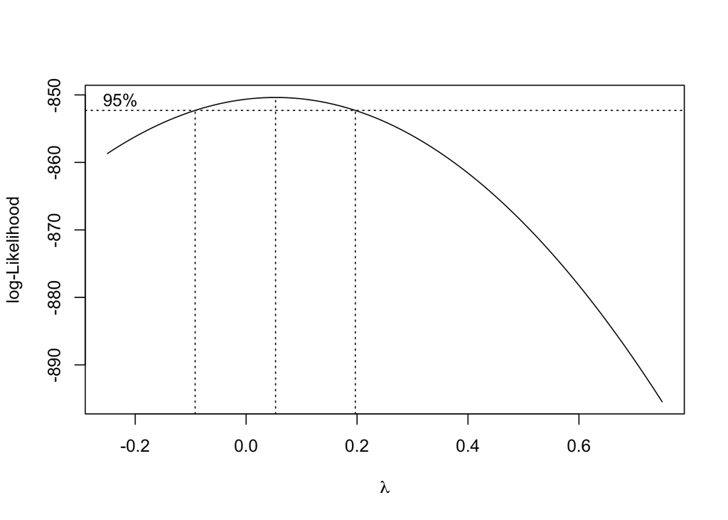

```
## [1] 0.0530303
```

According to the plot, and the print out, we can tell that $\hat{\lambda} = .05303$. So we will be performing an OLS regression with $\text{price}^{.05303}$ as the response and performing the Shapiro-Wilk test at the $\alpha = .05$ significance level.

```
##
##  Shapiro-Wilk normality test
##
## data:  resid(model_bc)
## W = 0.99525, p-value = 0.0939
```

The value of our test-statistic is 0.9953 and our $p$-value is 0.0939. We accept the null hypothesis at the $\alpha = .05$ significance level and conclude that the errors are now normally distributed.

We will also check the RMSE and the percent variation in price explained by both models.

| Model | RMSE | % Variation |
| --- | --- | --- |
| Standard Model | 1054129 | 68 |
| Transformed Model | 1041366 | 69 |

Since our errors are now normally distributed, we will use the transformed model instead of the standard model.

#### Linearity Assumption

It is clear that there is some linear relationship between the response and the numerical predictors (area, bathrooms, bedrooms, stories, parking).

#### Highly Influential Points

```
## [1] 35
```

To check for highly influential points, we will be checking the cooks distances of the data. Using this distance, we find that there are 35 highly influential points. We will check to see if removing these points from the model will in any way correct our models assumption violations. First we will check the constant variance assumption at the $\alpha$ = .05 significance level.

```
##
##  studentized Breusch-Pagan test
##
## data:  model_fix
## BP = 31.917, df = 13, p-value = 0.002471
```

The value of our test-statistic is 31.917 and our $p$-value is .00247. We reject the null hypothesis at the $\alpha = .05$ significance level and conclude that constant variance assumption is violated.

```
##
##  Shapiro-Wilk normality test
##
## data:  resid(model_fix)
## W = 0.99865, p-value = 0.9681
```

The value of our test-statistic is .9987 and our $p$-value is .9681. We accept the null hypothesis at the $\alpha = .05$ significance level and conclude that errors are still normally distributed.

We will also check the $R^2$ of both models,

```
## [1] 0.6818018
```

```
## [1] 0.7651252
```

| Model | $R^2$ |
| --- | --- |
| Standard Model | .682 |
| Model with Influential Points Removed | .765 |

It is clear that the Model with Influential Points removed is the preferred model as it explains almost 8% more of the observed variability in price with the predictors.

#### Outliers

To check for outliers we will be using the studentized residuals at the $\alpha$ = .05 significance level.

```
## [1] 0
```

We can see that there are zero outliers, so we move on. Our model now has normally distributed errors, however the equal variance assumption is violated. Therefore, we will look to use a regression method other than ordinary least squares. Since our errors are not correlated (heteroscedastic) we will use weighted least squares.

### Weighted Least Squares (WLS)

We now begin performing the weighted least squares regression. We create a model using the absolute values of the residual and then calculate weights as $\frac{1}{fitted values^2}$ . We then create our model with these weights.

After creating our model, we will perform a t-test at the 5% significance for each parameter for the OLS model and the WLS model.

Below are the estimates and p-values for the OLS regression:

| Coefficient | Estimate | P-value |
| --- | --- | --- |
| Intercept | 2.14 | 0.000 |
| area | 5.91e-06 | 2.69e-28 |
| bedrooms | 0.00307 | 0.0361 |
| bathrooms | 0.0203 | 1.74e-19 |
| stories | 0.0111 | 6.06e-17 |
| mainroadyes | 0.0111 | 0.000110 |
| guestroomyes | 0.00833 | 0.00206 |
| basementyes | 0.00896 | 0.000086 |
| hotwaterheatingyes | 0.0182 | 0.000538 |
| airconditioningyes | 0.0215 | 5.06e-21 |
| parking | 0.00519 | 0.0000168 |
| prefareayes | 0.0158 | 4.39e-11 |
| furnishingstatussemi-furnished | 0.000412 | 0.862 |
| furnishingstatusunfurnished | -0.0135 | 1.53e-07 |

Below are the estimates and p-values for the WLS regression:

| Coefficient | Estimate | P-value |
| --- | --- | --- |
| Intercept | 2.03e+05 | 0.315 |
| area | 236 | 4.09e-29 |
| bedrooms | 5.94e+04 | 0.312 |
| bathrooms | 9.73e+05 | 1.90e-31 |
| stories | 4.46e+05 | 1.83e-17 |
| mainroadyes | 4.14e+05 | 0.0000875 |
| guestroomyes | 3.14e+05 | 0.00219 |
| basementyes | 2.02e+05 | 0.0186 |
| hotwaterheatingyes | 8.42e+05 | 5.62e-07 |
| airconditioningyes | 8.47e+05 | 1.69e-22 |
| parking | 2.31e+05 | 1.50e-06 |
| prefareayes | 6.59e+05 | 1.33e-13 |
| furnishingstatussemi-furnished | -15.5e+03 | 0.860 |
| furnishingstatusunfurnished | -3.71e+05 | 0.000411 |

For OLS every variable is significant except furnishing status semi-furnished. For WLS every variable is significant except bedrooms and furnishing status semi-furnished.

We now summarize both the OLS model and WLS model to see the $R^2$ scores and how they compare.

| Model | $R^2$ |
| --- | --- |
| OLS | 0.765 |
| WLS | 0.778 |